# 15- Factors

Augusto de Souza Cavalcanti

03/05/2021

# 15 Factors

## 15.1 Introduction

Fatores são usados para trabalhar com variáeis categóricas. Podem ser usados para apresentar vetores de caracteres sem ser em ordem alfabética.

Como fatores eram muito mais fáceis de serem usados que caracteres, muitas funções do r já fazem uma transformação autómatica. Muitas vezes isso causa que fatores apareçam onde não são necessários, no tidyverse não temos que nos preocupar com isso, mas funções da base podem fazer isso.

## 15.2 Creating Factors

Imagina que temos uma variável para os meses do ano.

```r
meses <- c("Dec","Ago","Fev","Sep")
```

Usar strings para representar os meses tem dois problemas:

- Existem apenas 12 meses e cometer um erro tipográfico pode acontecer.

```r
x2 <- c("Jan","Fev","Mar","Abt")
```

- Não é ordenado em uma ordem útil.

```r
sort(meses)
```

```
## [1] "Ago" "Dec" "Fev" "Sep"
```

Esses dois problemas podem ser resolvidos por meio de fatores. Para criar um fator primeiro criamos uma lista ou vetor de níveis válidos.

```r
month_levels <- c(
  "Jan", "Fev", "Mar", "Abr", "Mai", "Jun",
  "Jul", "Ago", "Set", "Out", "Nov", "Dez"
)
```

```r
y1 <- factor(month_levels,levels = month_levels)
```

```r
sort(y1)
```

```
##  [1] Jan Fev Mar Abr Mai Jun Jul Ago Set Out Nov Dez
## Levels: Jan Fev Mar Abr Mai Jun Jul Ago Set Out Nov Dez
```

Qualquer valor que for inserido que não pertencer ao fator será transformado em NA.

```r
x <- factor(c(x2),levels = month_levels)
x
```

```
## [1] Jan  Fev  Mar  <NA>
## Levels: Jan Fev Mar Abr Mai Jun Jul Ago Set Out Nov Dez
```

As vezes desejamos que os níveis do fator sejam definidos pela ordem da primeira aparição no vetor, para isso use unique() ou fct_inorder() após a criação.

```r
f1 <- factor(meses, levels = unique(meses))
f1
```

```
## [1] Dec Ago Fev Sep
## Levels: Dec Ago Fev Sep
```

```r
f2 <- meses %>% factor() %>% fct_inorder()
f2
```

```
## [1] Dec Ago Fev Sep
## Levels: Dec Ago Fev Sep
```

Para acessar os níveis basta usar levels()

```r
levels(y1)
```

```
##  [1] "Jan" "Fev" "Mar" "Abr" "Mai" "Jun" "Jul" "Ago" "Set" "Out" "Nov" "Dez"
```

## 15.3 General Social Survey

Pelo resto do cápitulo vamos focar no forcats:gss_cat. É uma amostra de dados do General Social Survey. Uma enquete conduzida nos EUA para que a população informe diversas coisas sobre a sociedade e si mesmos. Parecido com o censo mas não é a mesma coisa.

```r
gss_cat
```

```
## # A tibble: 21,483 x 9
##     year marital     age race  rincome    partyid     relig     denom    tvhours
##    <int> <fct>     <int> <fct> <fct>      <fct>       <fct>     <fct>      <int>
##  1  2000 Never ma~    26 White $8000 to ~ Ind,near r~ Protesta~ Souther~      12
##  2  2000 Divorced     48 White $8000 to ~ Not str re~ Protesta~ Baptist~      NA
##  3  2000 Widowed      67 White Not appli~ Independent Protesta~ No deno~       2
##  4  2000 Never ma~    39 White Not appli~ Ind,near r~ Orthodox~ Not app~       4
##  5  2000 Divorced     25 White Not appli~ Not str de~ None      Not app~       1
##  6  2000 Married      25 White $20000 - ~ Strong dem~ Protesta~ Souther~      NA
##  7  2000 Never ma~    36 White $25000 or~ Not str re~ Christian Not app~       3
##  8  2000 Divorced     44 White $7000 to ~ Ind,near d~ Protesta~ Luthera~      NA
##  9  2000 Married      44 White $25000 or~ Not str de~ Protesta~ Other          0
## 10  2000 Married      47 White $25000 or~ Strong rep~ Protesta~ Souther~       3
## # ... with 21,473 more rows
```

Quando os dados estão em um tibble, é muito fácil ver os fatores, por meio de count ou um gráfico de barras.

```r
gss_cat %>% count(race)
```

```
## # A tibble: 3 x 2
##   race      n
##   <fct> <int>
## 1 Other  1959
## 2 Black  3129
## 3 White 16395
```

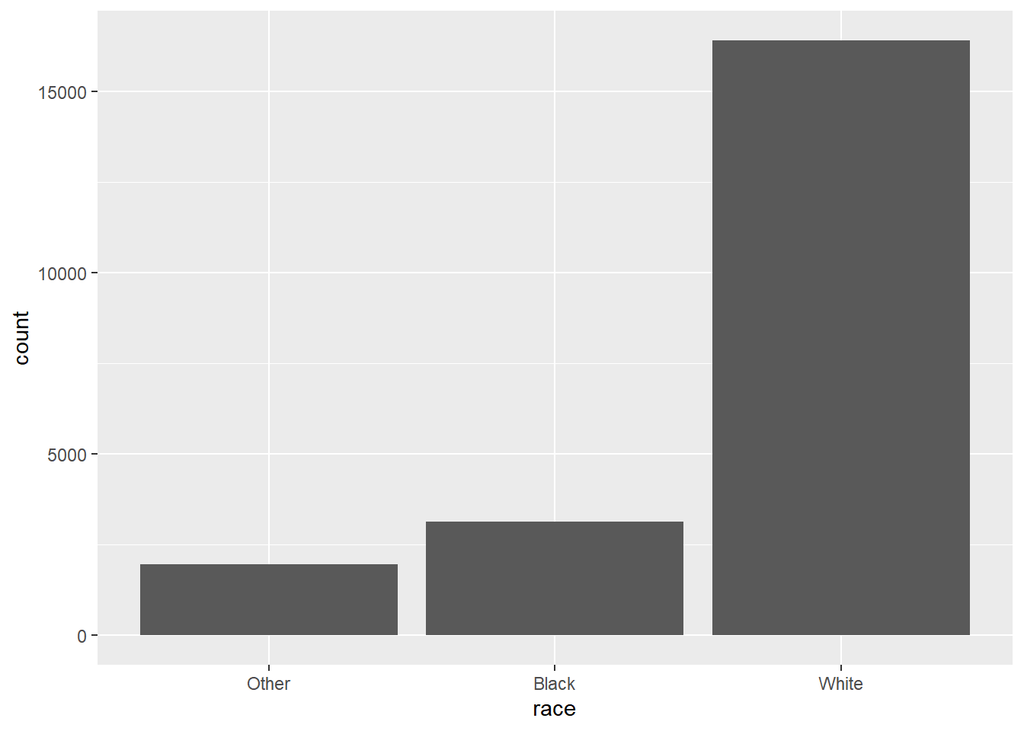

```r
gss_cat %>% ggplot(aes(race)) + geom_bar()
```

Por default o ggplot vai discartar níveis que não tiveram observações, podemos fazer com que eles apareçam com scale_x_discrete(drop=F)

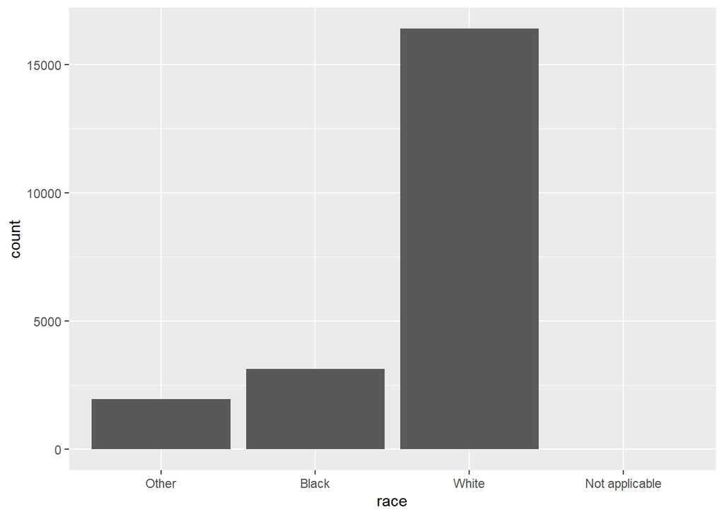

```r
gss_cat %>% ggplot(aes(race)) + geom_bar() + scale_x_discrete(drop=F)
```

As operações mais comuns com fatores são, alterar os níveis dos fatores e mudar os valores dos fatores. Ambas explicadas abaixo.

### Exercícios 15.3.1

1. Explore the distribution of rincome (reported income). What makes the default bar chart hard to understand? How could you improve the plot?

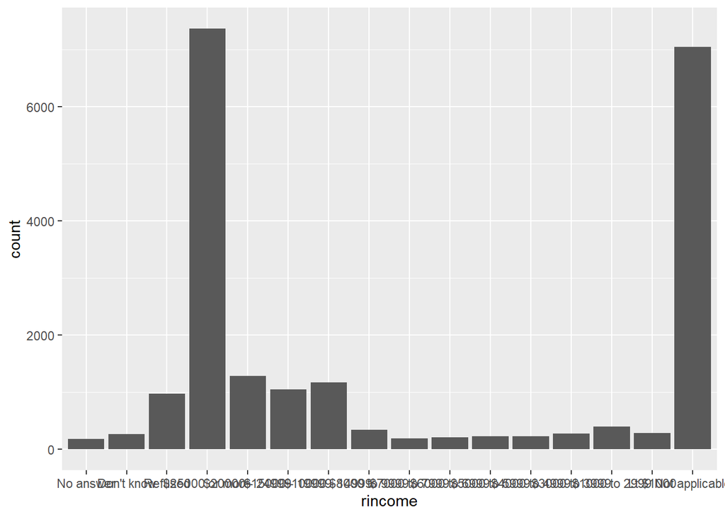

```r
gss_cat %>% ggplot(aes(rincome)) + geom_bar()
```

Temos dificuldades de ler devido ao tamanho do nome dos fatores, podemos virar o gráfico.

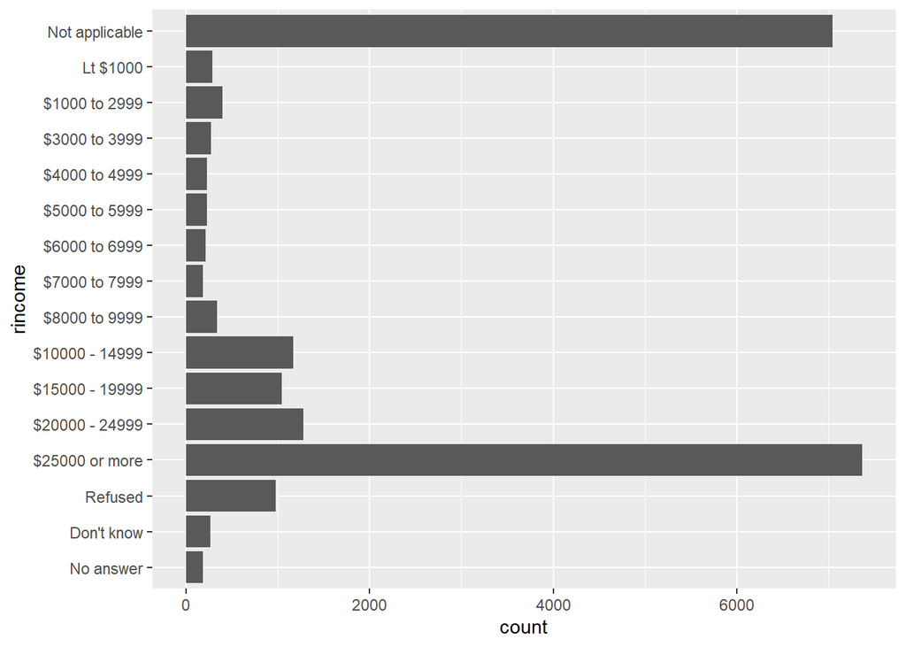

```r
gss_cat %>% ggplot(aes(rincome)) + geom_bar() + coord_flip()
```

Existem outras maneiras de alterar o gráfico positivamente, tanto para melhor leitura quanto codificação boa. Vou alterar apenas o angulo da escrita para um exemplo.

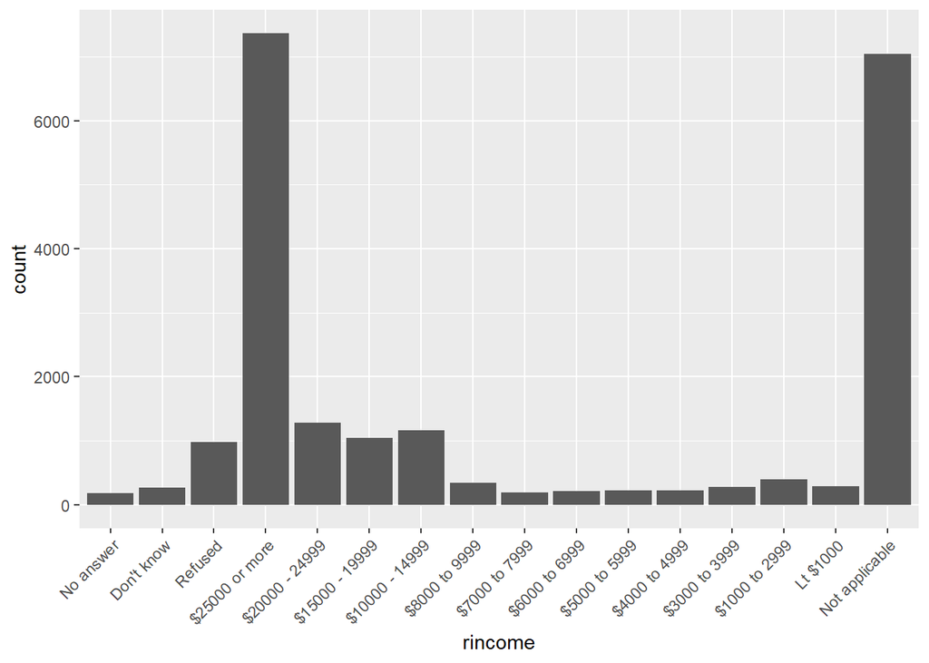

```r
gss_cat %>% ggplot(aes(rincome)) + geom_bar() + theme(axis.text.x= element_text(angle=45,hjust=1))
```

2. What is the most common relig in this survey? What’s the most common partyid?

```r
gss_cat %>% count(relig,sort=T) %>% head(1)
```

```
## # A tibble: 1 x 2
##   relig          n
##   <fct>      <int>
## 1 Protestant 10846
```

```r
gss_cat %>% count(partyid,sort=T) %>% head(1)
```

```
## # A tibble: 1 x 2
##   partyid         n
##   <fct>       <int>
## 1 Independent  4119
```

3. Which relig does denom (denomination) apply to? How can you find out with a table? How can you find out with a visualisation?

Table:

```r
gss_cat %>% group_by(relig,denom) %>% summarise(n())
```

```
## # A tibble: 47 x 3
## # Groups:   relig [15]
##    relig                   denom           `n()`
##    <fct>                   <fct>           <int>
##  1 No answer               No answer          93
##  2 Don't know              Not applicable     15
##  3 Inter-nondenominational Not applicable    109
##  4 Native american         Not applicable     23
##  5 Christian               No answer           2
##  6 Christian               Don't know         11
##  7 Christian               No denomination   452
##  8 Christian               Not applicable    224
##  9 Orthodox-christian      Not applicable     95
## 10 Moslem/islam            Not applicable    104
## # ... with 37 more rows
```

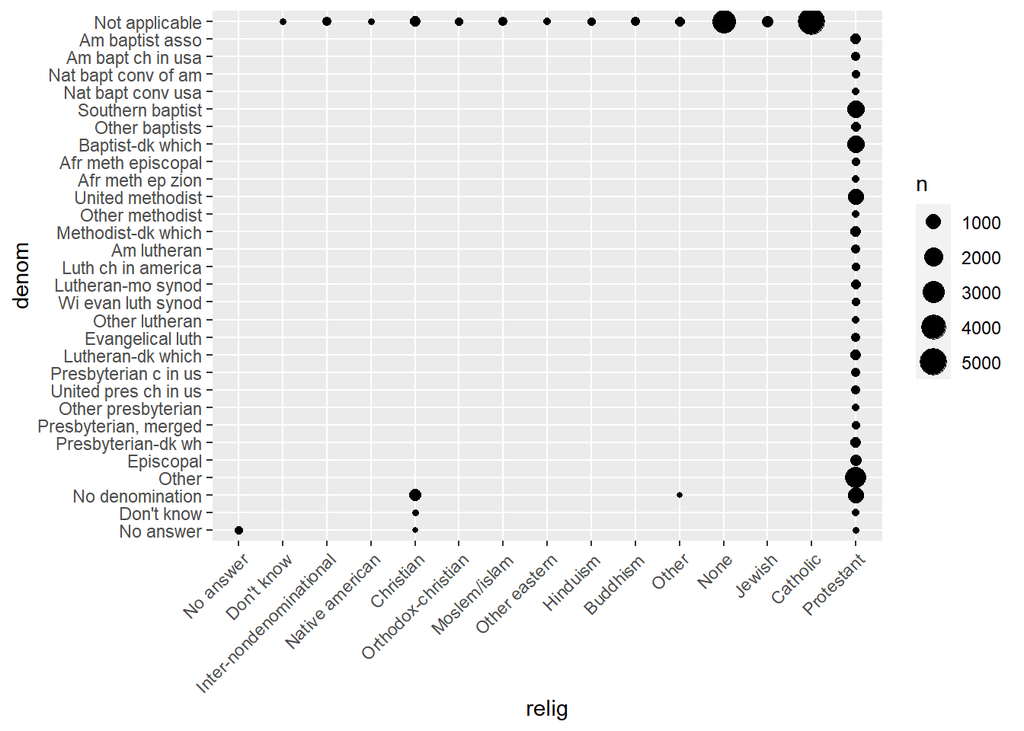

```r
gss_cat %>% count(relig,denom) %>% ggplot(aes(relig,denom,size=n)) + geom_point() + theme(axis.text.x = element_text(angle=45,hjust = 1))
```

Por meio do gráfico percebemos que claramente se trata de protestantes.

## 15.4 Modifying Factor Order

Podemos precisar mudar a ordem dos fators para um visualização. Imagine que você deseja explorar o tempo médio pasado por dia assistindo televisão, baseado nas religiões

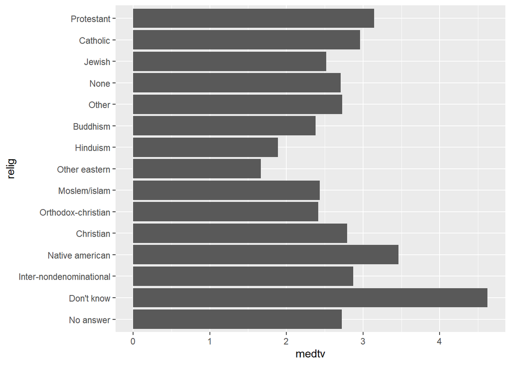

```r
summartvreg <- gss_cat %>% group_by(relig) %>% summarise(medtv = mean(tvhours,na.rm=T))

summartvreg %>% ggplot(aes(x=medtv,y=relig)) + geom_bar(stat="identity")
```

Esse gráfico é difícil de se interpretar pois não temos um padrão. Podemos mudar isso usando fct_reorder() que recebe três argumentos.

- f = O fator que os níveis podem ser alterados
- x = Um vetor númerico que deseja usar para reordenar
- fun = (OPCIONAL) Função que pode ser usada se existem várias observações para um fator.

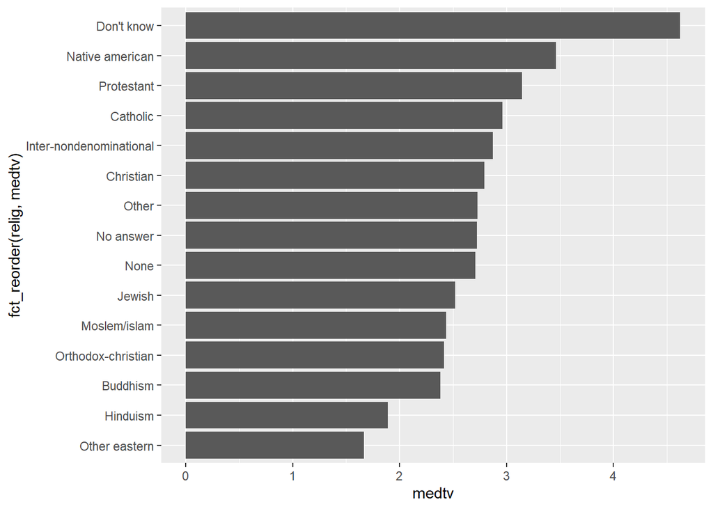

```r
summartvreg %>% ggplot(aes(medtv,fct_reorder(relig,medtv))) + geom_bar(stat="identity")
```

Essa reordenação permite que visualizemos os maiores e menores com mais facilidade. A partir do momento que fazemos transformações mais complexas, é recomendado mudar isso para o mutate antes e não o aes. Feito a seguir.

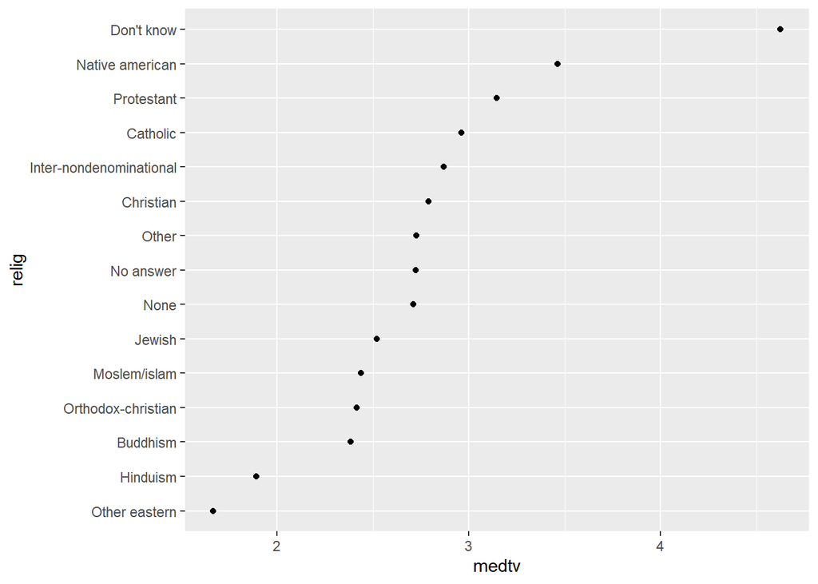

```r
summartvreg  %>%
  mutate(relig = fct_reorder(relig, medtv)) %>%
  ggplot(aes(medtv, relig)) +
    geom_point()
```

Poderiamos também criar um gráfico da idade média das pessoas para cada nível de income.

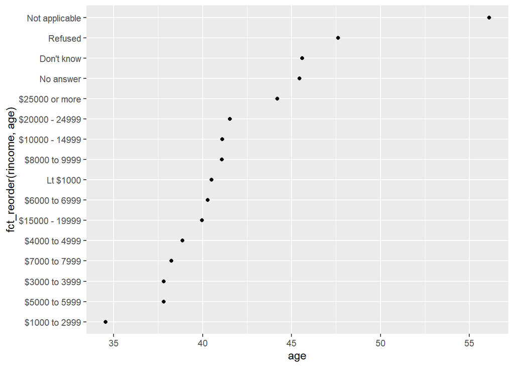

```r
rincome_summary <- gss_cat %>%
  group_by(rincome) %>%
  summarise(
    age = mean(age, na.rm = TRUE),
    tvhours = mean(tvhours, na.rm = TRUE),
    n = n()
  )

ggplot(rincome_summary, aes(age, fct_reorder(rincome, age))) + geom_point()
```

Nesse caso, mudar a ordem dos fatores não é uma boa ideia. O fato do income já ter uma ordem própria faz com que essa mudança não tenha sentido e cause mais trabalho ao analisar o gráfico. Porém faz sentido colocar not applicable junto com os outros níveis especiais. Podemos usar fct_relevel() para isso.

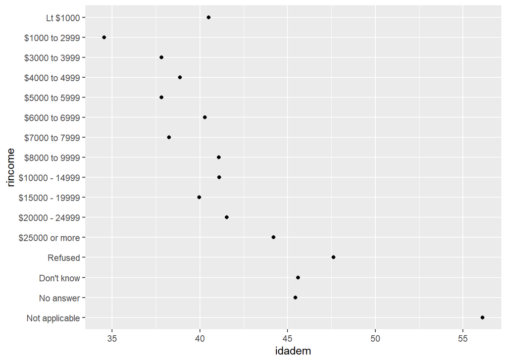

```r
gss_cat %>% group_by(rincome) %>% summarise(idadem = mean(age,na.rm = T)) %>% mutate(rincome = fct_relevel(rincome,"Not applicable")) %>% ggplot(aes(x=idadem,rincome)) + geom_point()
```

A idade média para não aplicável é alta provavelmente devido a aposentados.

Outro tipo de reordenação que pode ser útil quando colorindo linhas de um gráfico é fct_reorder2() pois reordena os fatores pelos valores de y associados com os maiores valores de x. Isso faz com que a cor das linhas se encaixe com a legenda.

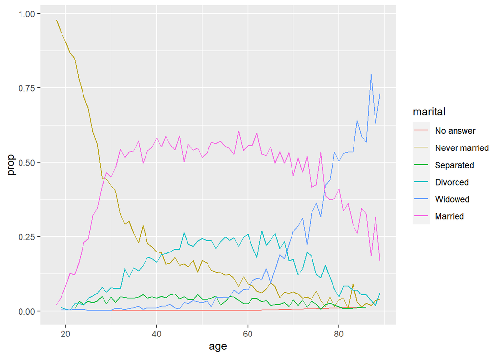

```r
by_age <- gss_cat %>%
  filter(!is.na(age)) %>%
  count(age, marital) %>%
  group_by(age) %>%
  mutate(prop = n / sum(n))

ggplot(by_age, aes(age, prop, colour = marital)) +
  geom_line(na.rm = TRUE)
```

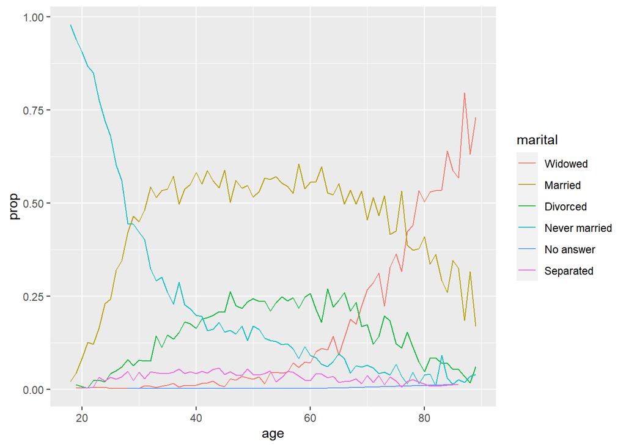

```r
ggplot(by_age, aes(age, prop, colour = fct_reorder2(marital, age, prop))) +
  geom_line() +
  labs(colour = "marital")
```

Finalmente, para gráficos de barra. Podemos usar fct_infreq() para ordenar os níveis em relação à frequência. Não é necessário nenhum argumento extra, pode ser combinado com freq_rev() para a visualização.

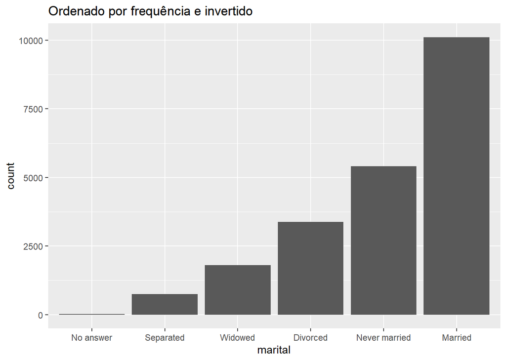

```r
gss_cat %>% mutate(marital = marital %>% fct_infreq() %>% fct_rev()) %>%  ggplot(aes(marital)) + geom_bar() + labs(title = "Ordenado por frequência e invertido")
```

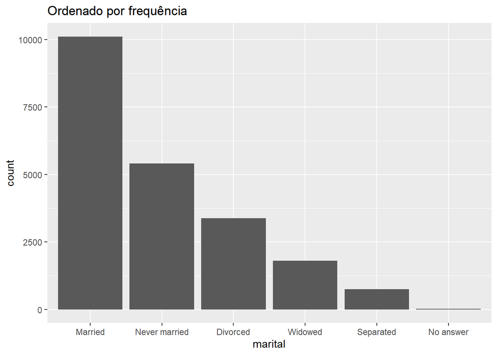

```r
gss_cat %>% mutate(marital = marital %>% fct_infreq()) %>%  ggplot(aes(marital)) + geom_bar() + labs(title = "Ordenado por frequência")
```

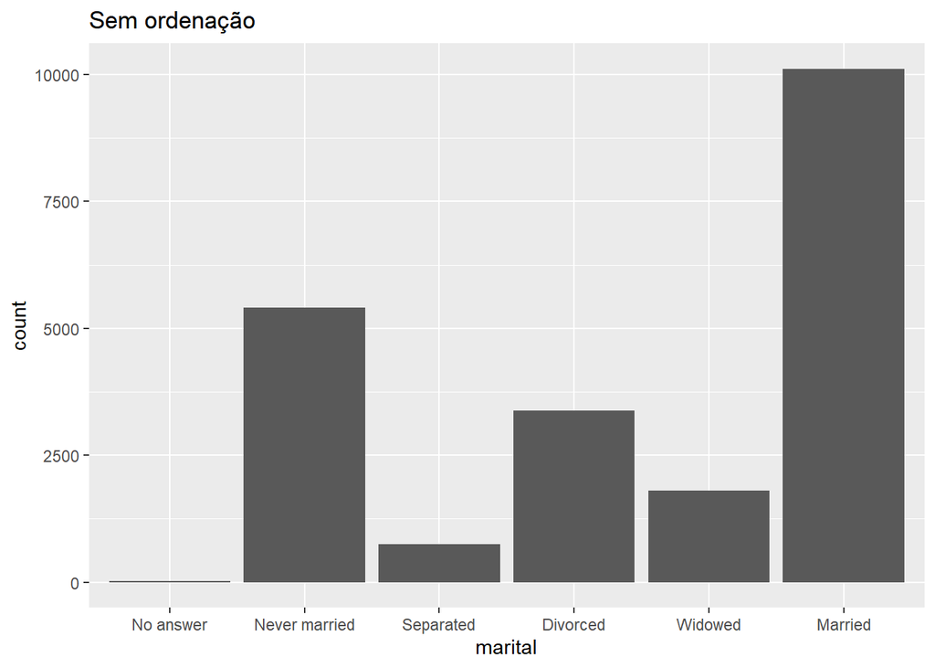

```r
gss_cat %>% ggplot(aes(marital)) + geom_bar() + labs(title = "Sem ordenação")
```

### Exercícios 15.4.1

1. There are some suspiciously high numbers in tvhours. Is the mean a good summary?

```r
gss_cat$tvhours %>% summary
```

```
##    Min. 1st Qu.  Median    Mean 3rd Qu.    Max.    NA's
##   0.000   1.000   2.000   2.981   4.000  24.000   10146
```

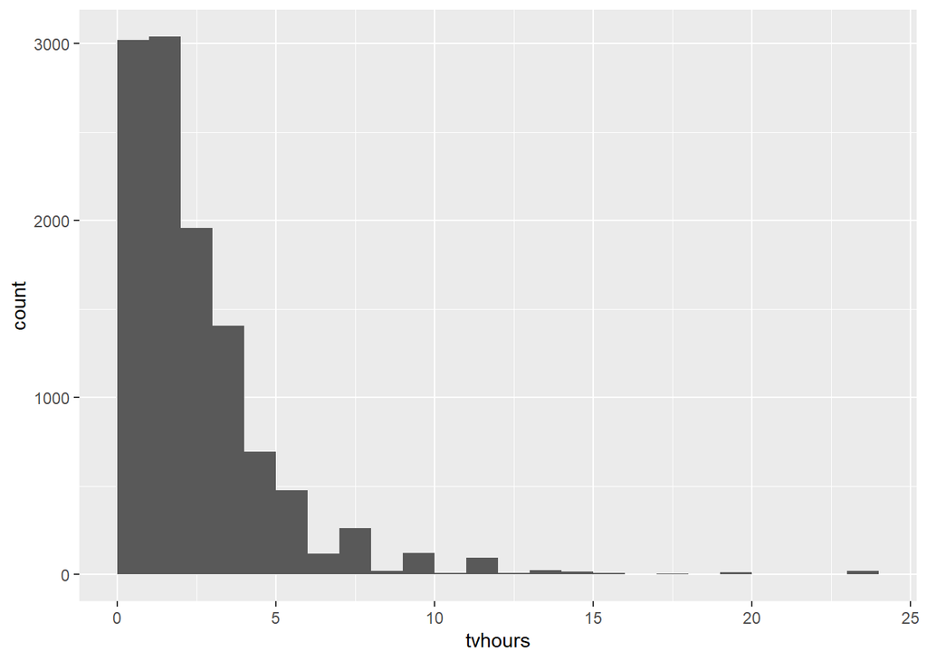

```r
gss_cat %>% ggplot(aes(tvhours)) + geom_histogram(binwidth = 1,center=0.5)
```

A média se difere da bastante da mediana, pelo fato de algumas pessoas assistirem por muitas horas ou responderem de maneira errada, podemos dizer que pode não ser o ideal. Mas podemos pedir uma média truncada para remover os outliers e percebemos que a média caí.

```r
gss_cat$tvhours %>% mean(trim=0.05,na.rm=T)
```

```
## [1] 2.697305
```

2. For each factor in gss_cat identify whether the order of the levels is arbitrary or principled.
- Marital = Ordem arbitrária (Nominal) # Podemos discutir se faz sentido ordenar por existir uma relação com a fase da vida que estamos
- Race = Ordem arbitrária (Nominal)
- rincome = Ordem Importa (Ordinária)
- Partyid = Ordem arbitrária (Nominal)
- relig = Ordem arbitrária (Nominal)
- denom = Ordem arbitrária (Nominal)
3. Why did moving “Not applicable” to the front of the levels move it to the bottom of the plot?

Pois assim ele recebe o valor de nível 1.

## 15.5 Modifying Factor Levels

Mais poderoso do que mudar a ordemo dos fatores é mudar seus valores. Podemos fazer isso com fct_recode().

Olhando para partyid por exemplo, vemos que os níveis são confusos.

```r
gss_cat %>% count(partyid)
```

```
## # A tibble: 10 x 2
##    partyid                n
##    <fct>              <int>
##  1 No answer            154
##  2 Don't know             1
##  3 Other party          393
##  4 Strong republican   2314
##  5 Not str republican  3032
##  6 Ind,near rep        1791
##  7 Independent         4119
##  8 Ind,near dem        2499
##  9 Not str democrat    3690
## 10 Strong democrat     3490
```

Podemos alterar eles para serem mais consistentes.

```r
gss_cat %>%
  mutate(partyid = fct_recode(partyid,
    "Republican, strong"    = "Strong republican",
    "Republican, weak"      = "Not str republican",
    "Independent, near rep" = "Ind,near rep",
    "Independent, near dem" = "Ind,near dem",
    "Democrat, weak"        = "Not str democrat",
    "Democrat, strong"      = "Strong democrat"
  )) %>%
  count(partyid)
```

```
## # A tibble: 10 x 2
##    partyid                   n
##    <fct>                 <int>
##  1 No answer               154
##  2 Don't know                1
##  3 Other party             393
##  4 Republican, strong     2314
##  5 Republican, weak       3032
##  6 Independent, near rep  1791
##  7 Independent            4119
##  8 Independent, near dem  2499
##  9 Democrat, weak         3690
## 10 Democrat, strong       3490
```

Níveis não informados serão mantidos e podemos agrupar dois níveis diferentes em uníco dando o mesmo nome.

```r
gss_cat %>%
  mutate(partyid = fct_recode(partyid,
    "Republican, strong"    = "Strong republican",
    "Republican, weak"      = "Not str republican",
    "Independent, near rep" = "Ind,near rep",
    "Independent, near dem" = "Ind,near dem",
    "Democrat, weak"        = "Not str democrat",
    "Democrat, strong"      = "Strong democrat",
    "Other"                 = "No answer",
    "Other"                 = "Don't know",
    "Other"                 = "Other party"
  )) %>%
  count(partyid)
```

```
## # A tibble: 8 x 2
##   partyid                   n
##   <fct>                 <int>
## 1 Other                   548
## 2 Republican, strong     2314
## 3 Republican, weak       3032
## 4 Independent, near rep  1791
## 5 Independent            4119
## 6 Independent, near dem  2499
## 7 Democrat, weak         3690
## 8 Democrat, strong       3490
```

Se desejar colapsar vários níveis, fct_collapse é uma variante útil de fct_recode()

```r
gss_cat %>%
  mutate(partyid = fct_collapse(partyid,
    other = c("No answer", "Don't know", "Other party"),
    rep = c("Strong republican", "Not str republican"),
    ind = c("Ind,near rep", "Independent", "Ind,near dem"),
    dem = c("Not str democrat", "Strong democrat")
  )) %>%
  count(partyid)
```

```
## # A tibble: 4 x 2
##   partyid     n
##   <fct>   <int>
## 1 other     548
## 2 rep      5346
## 3 ind      8409
## 4 dem      7180
```

Se quisermos juntar todos grupos pequenos para um grupo de outros por exemplo, podemos fazer isso com fct_lump(). Essa função faz com que os grupos menores sejam somados progressivemente enquanto esse ainda for o menor grupo.

```r
gss_cat %>%
  mutate(relig = fct_lump(relig)) %>%
  count(relig)
```

```
## # A tibble: 2 x 2
##   relig          n
##   <fct>      <int>
## 1 Protestant 10846
## 2 Other      10637
```

Nesse caso não é muito útil.

Podemos também informar o parâmetro n para dizer quantos grupos desejamos.

```r
gss_cat %>%
  mutate(relig = fct_lump(relig, n = 10)) %>%
  count(relig, sort = TRUE)
```

```
## # A tibble: 10 x 2
##    relig                       n
##    <fct>                   <int>
##  1 Protestant              10846
##  2 Catholic                 5124
##  3 None                     3523
##  4 Christian                 689
##  5 Other                     458
##  6 Jewish                    388
##  7 Buddhism                  147
##  8 Inter-nondenominational   109
##  9 Moslem/islam              104
## 10 Orthodox-christian         95
```

### Exercícios 15.5.1

1. How have the proportions of people identifying as Democrat, Republican, and Independent changed over time?

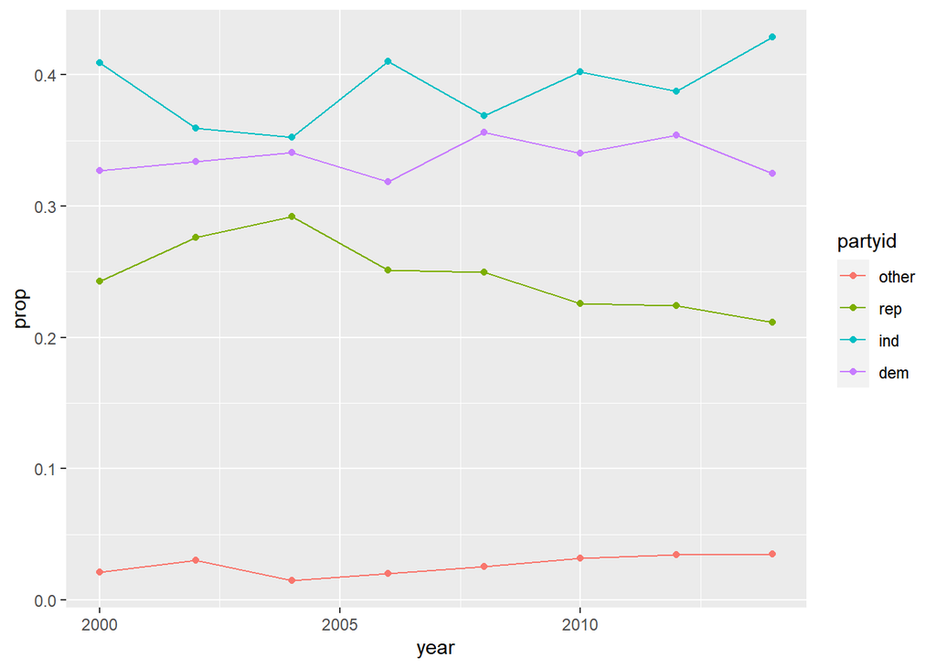

```r
gss_cat %>%
  mutate(partyid = fct_collapse(partyid,
    other = c("No answer", "Don't know", "Other party"),
    rep = c("Strong republican", "Not str republican"),
    ind = c("Ind,near rep", "Independent", "Ind,near dem"),
    dem = c("Not str democrat", "Strong democrat")
  )) %>% group_by(year,partyid) %>% summarise(totalp = n()) %>%
  ungroup() %>% group_by(year) %>% mutate(prop = totalp/sum(totalp)) %>%
  ggplot(aes(x=year,y=prop,color=partyid)) + geom_line() + geom_point()
```

O número de republicanos desceu um pouco ao longo do período, e o de independentes subiu um pouco (~3%) .Outros tiveram pequenas flutuações mas no geral foram mais estáveis.

2. How could you collapse rincome into a small set of categories?

```r
gss_cat %>% mutate(rincome = fct_collapse(rincome,
  outro = c("No answer","Don't know","Refused"),
  less6k = c("$5000 to 5999","$4000 to 4999","$3000 to 3999","$1000 to 2999","Lt $1000"),
  bettwen6_10k = c("$8000 to 9999", "$7000 to 7999",    "$6000 to 6999"),
  bettwen10_20k = c("$15000 - 19999","$10000 - 14999"),
  morethan25k = c("$25000 or more", "$20000 - 24999"),
)) %>% mutate(rincome = fct_relevel(rincome,"outro",after=4)) %>% count(rincome)
```

```
## # A tibble: 6 x 2
##   rincome            n
##   <fct>          <int>
## 1 morethan25k     8646
## 2 bettwen10_20k   2216
## 3 bettwen6_10k     743
## 4 less6k          1410
## 5 outro           1425
## 6 Not applicable  7043
```